# HD5 in R

Edmund Hart

August 10, 2014

HDF5 is a format that allows the storage of large heterogeneous data sets with self-describing metadata. It support compression, parallel I/O, and easy data slicing which means large files don’t need to be completely read into RAM (a real benefit to `R`). Plus it has wide support in the many programming languages, `R` included. To be able to access HDF5 files, you’ll need to first install the base [HDF5 libraries](http://www.hdfgroup.org/HDF5/release/obtain5.html#obtain). It might also be useful to install [HDFview](http://www.hdfgroup.org/products/java/hdfview/) which will allow you to explore the contents of an HDF5 file easily.

The package we’ll be using in `rhdf` which is part of the [Bioconductor](http://www.bioconductor.org) suite of `R` packages

```r
#source("http://bioconductor.org/biocLite.R")
#biocLite("rhdf5")
library("rhdf5")
```

### Examining file contents

Often we won’t know what’s in an HDF5 file, and we will need to explore the underlying structure. So let’s load up a file and examine it’s contents.

```r
f <- "/Users/THART/scratch/neonESA2014/data/fiuTestFile.hdf5"
h5ls(f,all=T)
```

```
##                              group        name         ltype corder_valid
## 0                                /   Domain_03 H5L_TYPE_HARD        FALSE
## 1                       /Domain_03         Ord H5L_TYPE_HARD        FALSE
## 2                   /Domain_03/Ord       min_1 H5L_TYPE_HARD        FALSE
## 3             /Domain_03/Ord/min_1      boom_1 H5L_TYPE_HARD        FALSE
## 4      /Domain_03/Ord/min_1/boom_1 temperature H5L_TYPE_HARD        FALSE
## 5             /Domain_03/Ord/min_1      boom_2 H5L_TYPE_HARD        FALSE
## 6      /Domain_03/Ord/min_1/boom_2 temperature H5L_TYPE_HARD        FALSE
## 7             /Domain_03/Ord/min_1      boom_3 H5L_TYPE_HARD        FALSE
## 8      /Domain_03/Ord/min_1/boom_3 temperature H5L_TYPE_HARD        FALSE
## 9             /Domain_03/Ord/min_1      boom_5 H5L_TYPE_HARD        FALSE
## 10     /Domain_03/Ord/min_1/boom_5 temperature H5L_TYPE_HARD        FALSE
## 11            /Domain_03/Ord/min_1   tower_top H5L_TYPE_HARD        FALSE
## 12  /Domain_03/Ord/min_1/tower_top temperature H5L_TYPE_HARD        FALSE
## 13                  /Domain_03/Ord      min_30 H5L_TYPE_HARD        FALSE
```

[output cut: 108 more lines]

Note that it returns the group, the name of a particular node (which may be a group), the type, and class, and the dimensions of the object. In this case because the class is compound (meaning there are mixed data types), the dimensions are returned as the number of elements.

HDF5 files essentially function as a structured file system within a single file. It’s easy to dump the contents into a dataframe.

```r
temp <- h5read(f,"/Domain_03/Ord/min_1/boom_1/temperature")
head(temp)
```

```
##                    date numPts  mean   min   max variance   stdErr
## 1 2014-04-01 00:00:00.0     60 15.06 14.97 15.16 0.002655 0.006652
## 2 2014-04-01 00:01:00.0     60 15.00 14.94 15.04 0.001254 0.004572
## 3 2014-04-01 00:02:00.0     60 15.26 15.04 15.57 0.041438 0.026280
## 4 2014-04-01 00:03:00.0     60 15.45 15.39 15.53 0.001175 0.004425
## 5 2014-04-01 00:04:00.0     60 15.35 15.24 15.42 0.003526 0.007666
## 6 2014-04-01 00:05:00.0     60 15.13 15.06 15.23 0.003764 0.007921
##   uncertainty
## 1     0.01620
## 2     0.01306
## 3     0.05350
## 4     0.01287
## 5     0.01788
## 6     0.01831
```

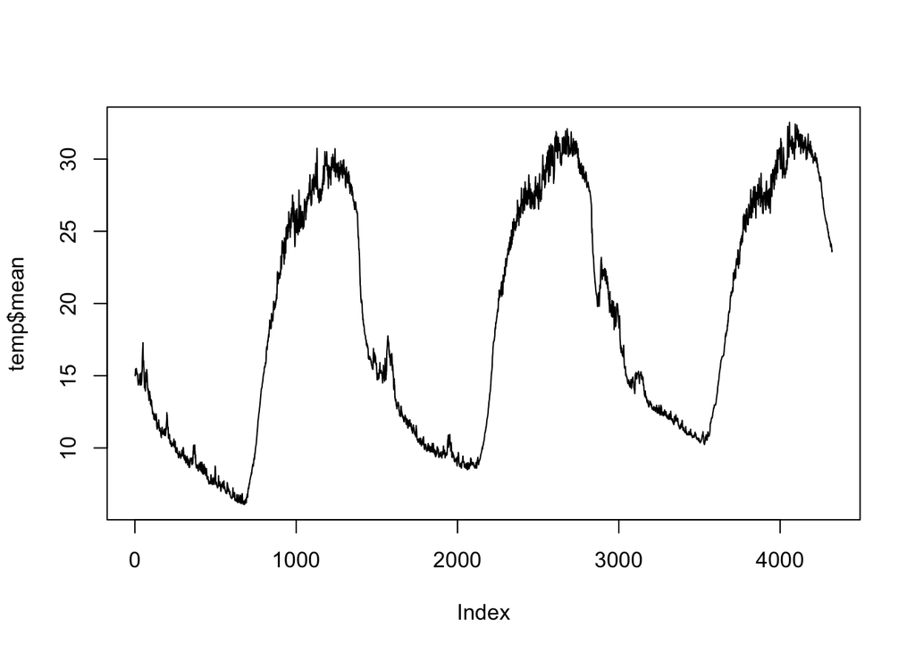

```r
plot(temp$mean,type='l')
```

### Extracting metadata

It’s that simple to extract a single table from an HDF5 file. Another great advantage of HDF5 is that it’s self describing, so metadata is embedded in the file. However the best way to access it via the low level HDF5 API

```r
# Open file
out <- H5Fopen(f)
# open a group
g <- H5Gopen(out,'/Domain_03/Ord')
a <- H5Aopen_by_idx(g,1)
H5Aget_name(a)
```

```
## [1] "Site Name"
```

```r
aval <- H5Aread(a)
aval
```

```
## [1] "Ordway-Swisher Biological Station Site"
```

```r
### Lastly we need to close the file
H5Aclose(a)
H5Gclose(g)
H5Fclose(out)
```

But this is really tedious. We can easily create a simple function that can extract all the metadata from any group.

```r
h5metadata <- function(fileN, group, natt){
  out <- H5Fopen(fileN)
  g <- H5Gopen(out,group)
  output <- list()
  for(i in 0:(natt-1)){
    ## Open the attribute
    a <- H5Aopen_by_idx(g,i)
    output[H5Aget_name(a)] <-  H5Aread(a)
    ## Close the attributes
    H5Aclose(a)
  }
  H5Gclose(g)
  H5Fclose(out)
  return(output)
}
```

Now we can combine the information we get from `h5ls` with our metadata extraction function. This means we could easily loop through the whole file and extract metadata for every element.

```r
fiu_struct <- h5ls(f,all=T)
g <- paste(fiu_struct[2,1:2],collapse="/")
h5metadata(f,g,fiu_struct$num_attrs[2])
```

```
## $LatLon
## [1] "29.68927/-81.99343"
##
## $`Site Name`
## [1] "Ordway-Swisher Biological Station Site"
```

### Visualizing temperature differences

Now, let’s say we want to compare temeratures across sites, how can we build a dataframe to do this? We’ll use our knowledge of the structure of the HDF5 to easily loop through the file and build a new data frame. Let’s look at Domain 3, 1 minute series across all the booms.

```r
library(dplyr)
```

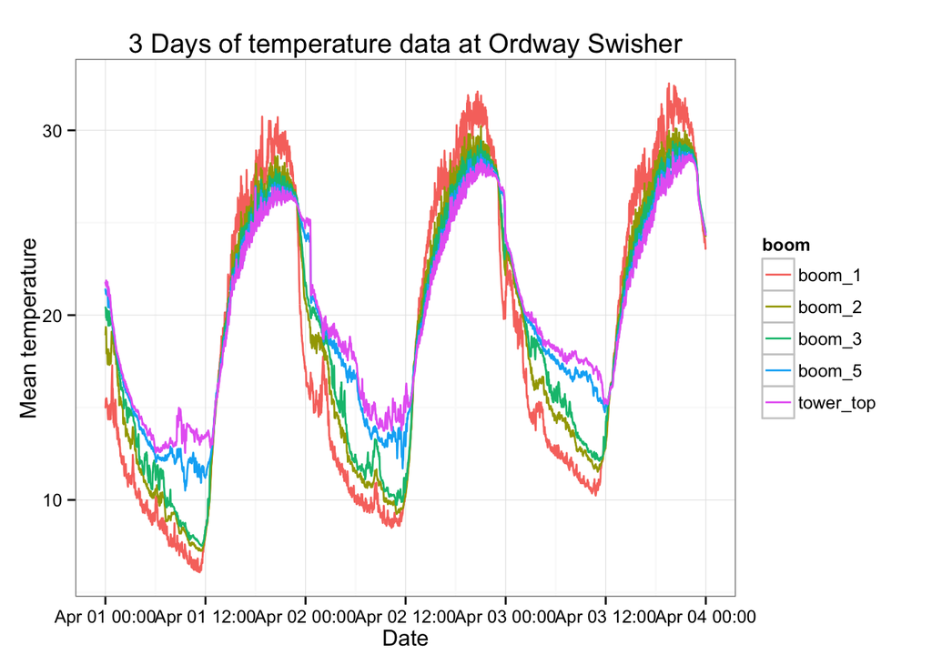

```r
library(ggplot2)
# Set the path string
s <- "/Domain_03/Ord/min_1"
### Grab the paths
paths <- fiu_struct %.% filter(grepl(s,group), grepl("DATA",otype)) %.% group_by(group) %.% summarise(path = paste(group,name,sep="/"))
ord_temp <- data.frame()
for(i in paths$path){
  boom <-  strsplit(i,"/")[[1]][5]
  dat <- h5read(f,i)
  dat$boom <- rep(boom,dim(dat)[1])
  ord_temp <- rbind(ord_temp,dat)
}
### Dates aren't dates though, so let's fix that
ord_temp$date <- as.POSIXct(ord_temp$date,format = "%Y-%m-%d %H:%M:%S", tz = "EST")
## Now we can make our plot!
ggplot(ord_temp,aes(x=date,y=mean,group=boom,colour=boom))+geom_path()+ylab("Mean temperature") + xlab("Date")+theme_bw()+ggtitle("3 Days of temperature data at Ordway Swisher")
```

Now, what if we want to compare temperatures at our two different sites? Well let’s do that but this time we’ll compare 30 minute averages. We’ll need to change up our search strings a bit. but we can still use most of the code we just build

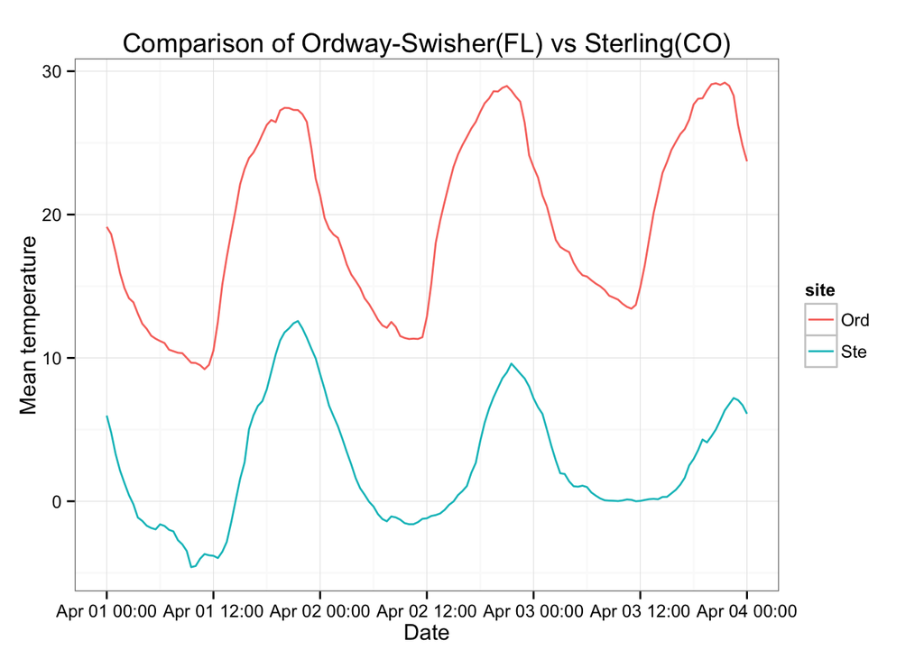

```r
### We want all sites in the minute 30 so this will help us prune our list
s <- "min_30"
### Grab the paths
paths <- fiu_struct %.% filter(grepl(s,group), grepl("DATA",otype)) %.% group_by(group) %.% summarise(path = paste(group,name,sep="/"))
temp_30 <- data.frame()
for(i in paths$path){
  boom <-  strsplit(i,"/")[[1]][5]
  site <- strsplit(i,"/")[[1]][3]
  dat <- h5read(f,i)
  dat$boom <- rep(boom,dim(dat)[1])
  dat$site <- rep(site,dim(dat)[1])
 temp_30 <- rbind(temp_30,dat)
}
### Dates aren't dates though, so let's fix that
temp_30$date <- as.POSIXct(temp_30$date,format = "%Y-%m-%d %H:%M:%S")

temp30_sum <- temp_30 %.% group_by(date,site) %.% summarise(mean = mean(mean))
ggplot(temp30_sum,aes(x=date,y=mean,group=site,colour=site)) + geom_path()+ylab("Mean temperature") + xlab("Date")+theme_bw()+ggtitle("Comparison of Ordway-Swisher(FL) vs Sterling(CO)")
```